# Praca domowa 2

Julia Michalska

## Dane

Dane wykorzystane w Pracy domowej 2 dotyczą wyników egzaminów z 3 umiejętności: czytania, pisania i operacji matematycznych. Dodatkowo dostępne są podstawowe informacje o studentach i ich rodzicach. Opis wszystkich kolumn znajduje się również w pliku `README.md`.

| Zmienna | Opis |
| --- | --- |
| **gender** | płeć |
| **race.ethnicity** | pochodzenie etniczne |
| **parental.level.of.education** | wykształcenie rodziców |
| **lunch** | jaki obiad jedli uczniowie w dniu egzaminu |
| **test.preparation.course** | czy uczeń odbył kurs przygotowujący |
| **math.score** | wynik egzaminu z matematyki |
| **reading.score** | wynik egzaminu z czytania |
| **writing.score** | wynik egzaminu z pisania |

## Zadanie 1

Jak wyglądają rozkłady wyników uczniów z trzech przedmiotów (matematyka, czytanie, pisanie)?

```r
grupy<- rep("math",dim(df)[1])
grupy<- c(grupy,rep("reading",dim(df)[1]))
grupy<- c(grupy,rep("writing",dim(df)[1]))
wyniki <- df %>% select(math.score,writing.score,reading.score)
summary(wyniki)
```

```
##    math.score     writing.score    reading.score
##  Min.   :  0.00   Min.   : 10.00   Min.   : 17.00
##  1st Qu.: 57.00   1st Qu.: 57.75   1st Qu.: 59.00
##  Median : 66.00   Median : 69.00   Median : 70.00
##  Mean   : 66.09   Mean   : 68.05   Mean   : 69.17
##  3rd Qu.: 77.00   3rd Qu.: 79.00   3rd Qu.: 79.00
##  Max.   :100.00   Max.   :100.00   Max.   :100.00
```

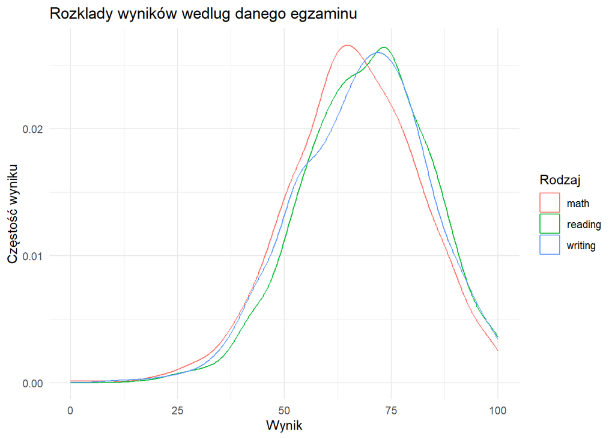

```r
wykres <-c(df$math.score,df$reading.score,df$writing.score)

wykres<-cbind(wykres,grupy)
colnames(wykres)<-c("wynik","rodzaj")
wykres<-data.frame(wykres)
wykres<-wykres %>% mutate(wynik = as.numeric(wynik))

wykres %>% ggplot(aes(x = wynik,group=rodzaj,color=rodzaj))+
  geom_density()+ labs(
    title = "Rozklady wyników wedlug danego egzaminu",
    x = "Wynik",
    y = "Częstość wyniku",
    color = "Rodzaj")+
  theme_minimal()
```

**Komentarz:** # Mediany i średnie z czytania i pisania są zbliżone, z matematyki są trochę niższe. # Mimo to ogólny rozkład wyników jest podobny, co widać po zasięgu 1 i 3 kwartyla

## Zadanie 2

Czy istnieje zauważalna różnica w wynikach między uczniami i uczennicami?

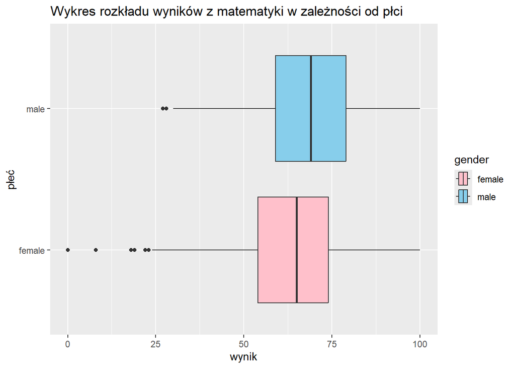

```r
ggplot(df, aes(x = math.score, y = gender, fill = gender)) +
  geom_boxplot() +
  scale_fill_manual(values = c("female" = "pink", "male" = "skyblue")) +
  labs(title = "Wykres rozkładu wyników z matematyki w zależności od płci",
       x = "wynik",
       y = "płeć")
```

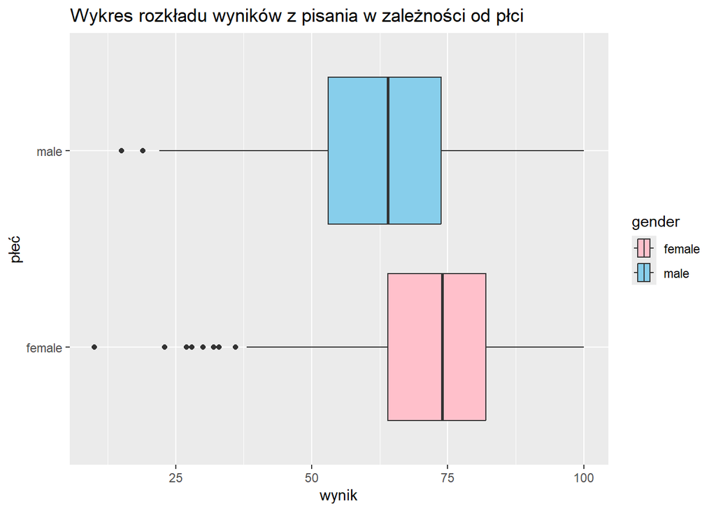

```r
ggplot(df, aes(x = writing.score, y = gender, fill = gender)) +
  geom_boxplot() +
  scale_fill_manual(values = c("female" = "pink", "male" = "skyblue")) +
  labs(title = "Wykres rozkładu wyników z pisania w zależności od płci",
       x = "wynik",
       y = "płeć")
```

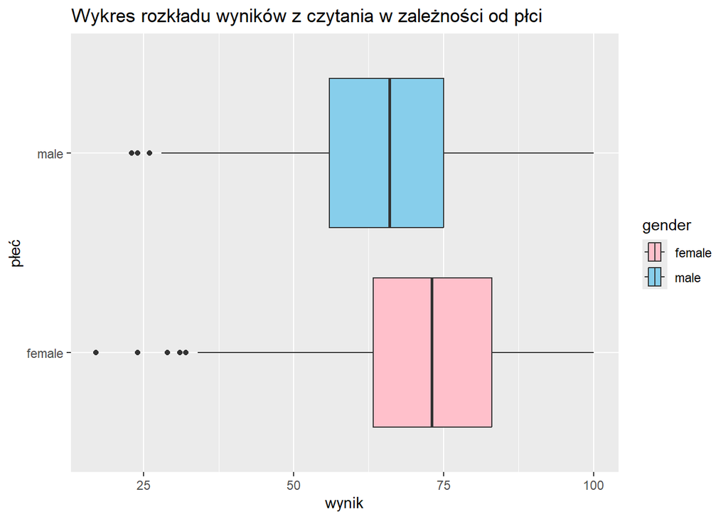

```r
ggplot(df, aes(x = reading.score, y = gender, fill = gender)) +
  geom_boxplot() +
  scale_fill_manual(values = c("female" = "pink", "male" = "skyblue")) +
  labs(title = "Wykres rozkładu wyników z czytania w zależności od płci",
       x = "wynik",
       y = "płeć")
```

**Komentarz:** #Uczniowie uzsyskują lepsze wyniki z matematyki, natomiast uczennice lepsze wyniki z #czytania i pisania.

## Zadanie 3

Czy uczniowie, którzy ukończyli kurs przygotowawczy, osiągają lepsze wyniki niż pozostali?

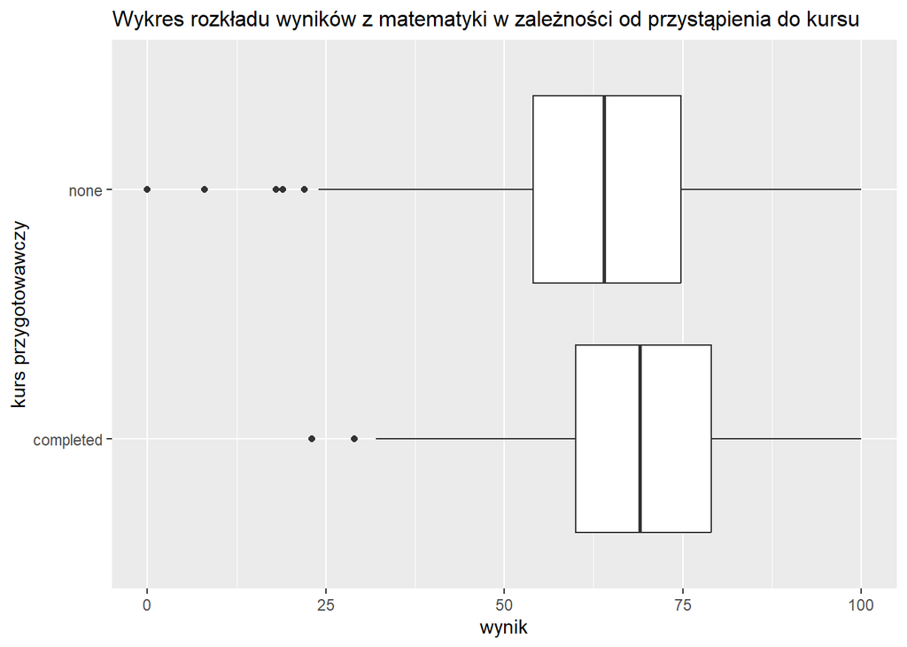

```r
ggplot(df,aes(x=math.score,y=test.preparation.course))+
  geom_boxplot()+
  labs(title="Wykres rozkładu wyników z matematyki w zależności od przystąpienia do kursu",
       x="wynik",
       y="kurs przygotowawczy")+
  theme(plot.title = element_text(size=12))
```

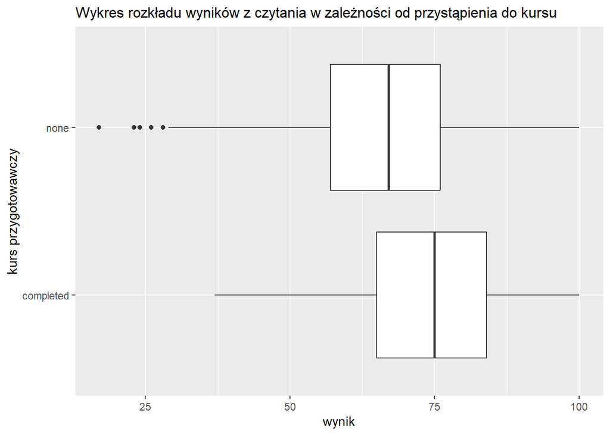

```r
ggplot(df,aes(x=reading.score,y=test.preparation.course))+
  geom_boxplot()+
  labs(title="Wykres rozkładu wyników z czytania w zależności od przystąpienia do kursu",
       x="wynik",
       y="kurs przygotowawczy")+
  theme(plot.title = element_text(size=12))
```

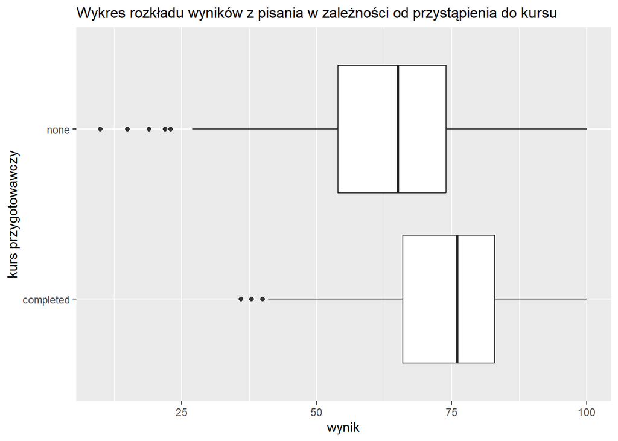

```r
ggplot(df,aes(x=writing.score,y=test.preparation.course))+
  geom_boxplot()+
  labs(title="Wykres rozkładu wyników z pisania w zależności od przystąpienia do kursu",
       x="wynik",
       y="kurs przygotowawczy")+
  theme(plot.title = element_text(size=12))
```

**Komentarz:** # We wszystkich trzech obszarach uczniowie po kursie przygotowawczym uzyskują wyższe wyniki, # przy czym najmniejsza przewaga widoczna jest w przypadku testu z matematyki.

## Zadanie 4

Jaki jest związek między poziomem wykształcenia rodziców a średnimi wynikami uczniów?

```r
wykres_rodz<- cbind(wykres,wyk_rodzica = df$parental.level.of.education)

wykres_rodz<- wykres_rodz %>% group_by(wyk_rodzica,rodzaj) %>%
  summarise(srednia = mean(wynik))
wykres_rodz
```

```
## # A tibble: 18 × 3
## # Groups:   wyk_rodzica [6]
##    wyk_rodzica        rodzaj  srednia
##    <chr>              <chr>     <dbl>
##  1 associate's degree math       67.9
##  2 associate's degree reading    70.9
##  3 associate's degree writing    69.9
##  4 bachelor's degree  math       69.4
##  5 bachelor's degree  reading    73
##  6 bachelor's degree  writing    73.4
##  7 high school        math       62.1
##  8 high school        reading    64.7
##  9 high school        writing    62.4
## 10 master's degree    math       69.7
## 11 master's degree    reading    75.4
## 12 master's degree    writing    75.7
## 13 some college       math       67.1
## 14 some college       reading    69.5
## 15 some college       writing    68.8
## 16 some high school   math       63.5
## 17 some high school   reading    66.9
## 18 some high school   writing    64.9
```

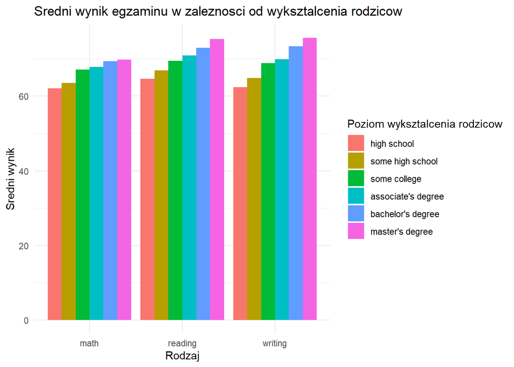

```r
wykres_rodz %>% ggplot(aes(x=rodzaj,y=srednia,fill=reorder(wyk_rodzica,srednia)))+
  geom_bar(position="dodge",stat="identity")+ labs(
    title = "Sredni wynik egzaminu w zaleznosci od wyksztalcenia rodzicow",
    x = "Rodzaj",
    y = "Sredni wynik",
    fill = "Poziom wyksztalcenia rodzicow")+
  theme_minimal()
```

## Zadanie 5

Czy płeć i wykształcenie rodzica wpływa na wynik z matematyki?

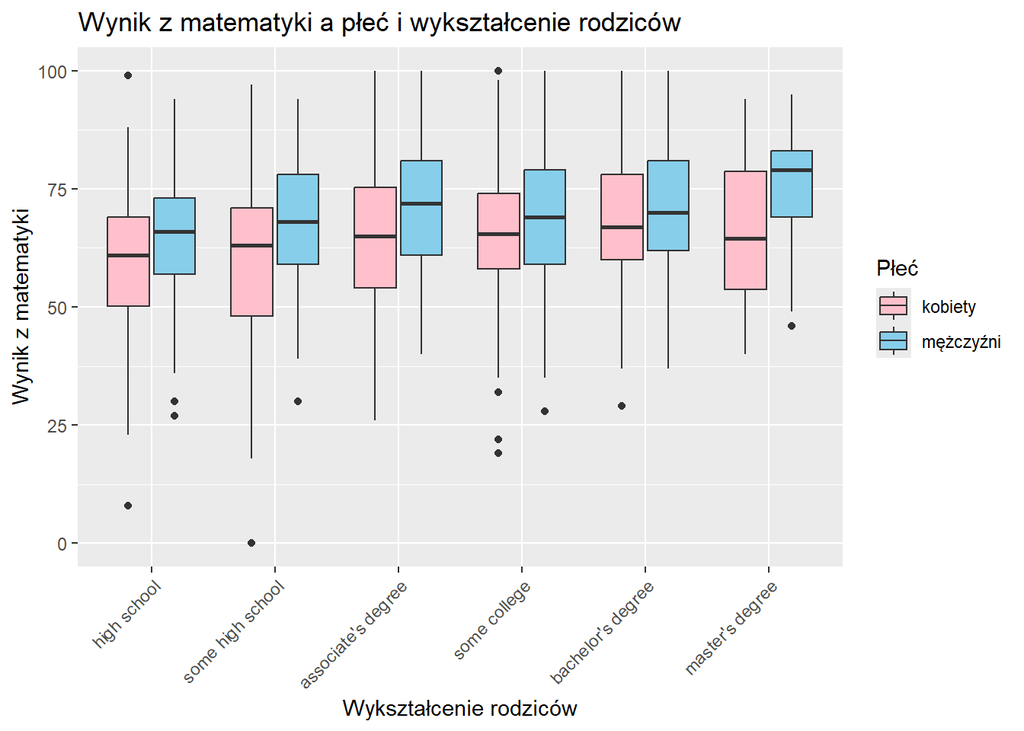

```r
ggplot(df, aes(x = reorder(`parental.level.of.education`, `math.score`, FUN = median), y = `math.score`, fill = gender)) +
  geom_boxplot() +
  labs(title = "Wynik z matematyki a płeć i wykształcenie rodziców",
       x = "Wykształcenie rodziców",
       y = "Wynik z matematyki",
       fill = "Płeć") +
  scale_fill_manual(
    values = c("pink", "skyblue"),
    labels=c("kobiety", "mężczyźni")) +
  theme(axis.text.x = element_text(angle = 45, hjust = 1))
```

**Komentarz:** #Wyniki z matematyki zależą jednocześnie od płci uczniów oraz od wykształcenia ich rodziców.

## Zadanie 6

Czy istnieje zależność między wynikami z matematyki a wynikami z czytania lub pisania?

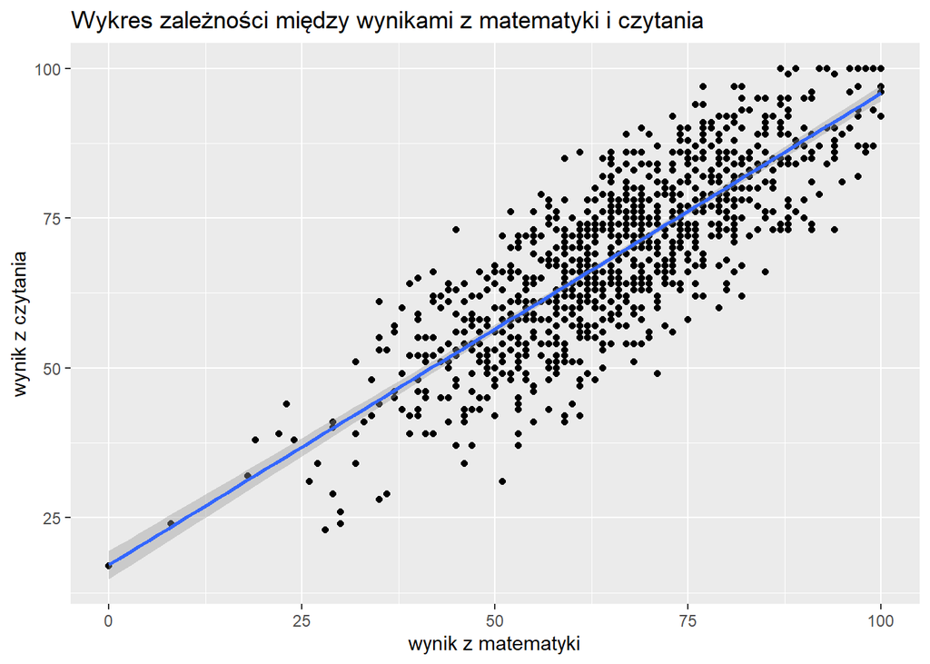

```r
ggplot(df,aes(x=math.score,y=reading.score))+
   geom_point()+
  geom_smooth(method = "lm")+
  labs(title="Wykres zależności między wynikami z matematyki i czytania",
       x="wynik z matematyki",
       y="wynik z czytania")
```

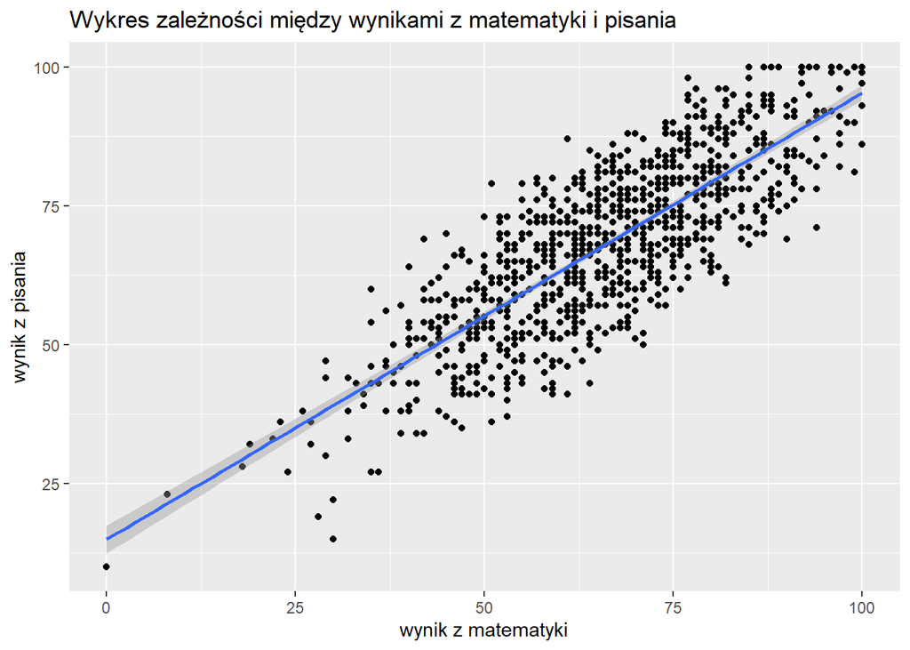

```r
  ggplot(df,aes(x=math.score,y=writing.score))+
  geom_point()+
  geom_smooth(method="lm")+
  labs(title="Wykres zależności między wynikami z matematyki i pisania",
       x="wynik z matematyki",
       y="wynik z pisania")
```

**Komentarz:** # Wyniki z matematyki zwiększają się proporcjonalnie do rezultatów z czytania i pisania, # jednak osiągnięcie wysokich rezultatów jest prostsze w przypadku czytania i pisania niż # matematyki.